# The relationship between stored resources and diapause preparation

### Page 2: 2018-01-05. Committee meeting following Research Proposal | Respirometry

Attendee’s: Dan Hahn, John Beck, Rob Meagher James’ take on proposal presentation Prior to delivering the talk at 0930 on Jan 5th 2018, I arrived in the seminar room at 0730a and tested the equipment and delivered a mock talk. I started from the begining (read: introduction/title slide) and ended with the thank you slide as though I was delivering it to an audience. During that time I felt confident and assured that I was doing well to hit all the marks. Specifically, I introduced information linearly, gave time for pauses, and engaged the audience (read: empty chairs) in eye contact. When the time came for the proposal presentation with the live audience I was a bit rattled. During the talk I tried to present the information as linearly as possible. However there were time that I feel I lost my train of thought. I think the loss of thought was a consequence of having not been as prepared as I could have been.

Committee comments following proposal Rob:

1. Literature - Rob is willing to assist me in reviewing literature that could assist me in better understand how ECB fits into its varied global ecology.
2. Confidence - Rob, in agreement with John and Dan, suggests that the question session after a seminar is the perfect time to speculate. Specifically, if someone asks me a question I may not necessarily know the answer to it is perfectly fine for me to say, “I do not know the answer, but here is what I think….”
3. Admin - I need to email Rob and schedule meeting times with him for the semester.

John:

1. Presentation tips: John would like my presentations to include expected questions from the audience. This could contexualize the Q&A session after my talk and possibly ensure I am prepared for said question session.

Dan:

1. Big picture - Dan would like to more growth from me and my research as it relates to a larger picture or perspective. Specifically, how does this work fit into the larger body of knowledge, why does my research matter (think IPM, big physiology questions, and evolution). When it comes to presenting my research to the scientific community or any community I need to make sure I am answering the question, “How does this work fill a gap in scientific knowledge?”.
2. Synthesis - The questions I was asked after my presentation suggest I am uncomfortable or less confident with synthesizing data or information on the fly (for lack of a better phrase). Dan suggests I read literature more broadly to better understand the relationship between my study system and its ecological position. Also I would benefit from continuing my education in evolution.
3. Admin - With Rob as a resource, I will be starting weekly or biweekly literature meetings with R. Meagher and Dan would like the contents of those meetings shared using GitHub.

Respirometry:

1. Larvae weighed and loaded into a 5mL syringe
2. Syringe air purged of CO2, and hydrated
3. Larvae held for ~1hr in syringe
4. Using a LiCor meter, the syringe air is analyzed for CO2 production.

Hourly production of CO2

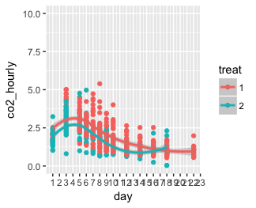

Hourly production of CO2 by mass

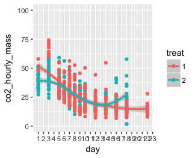

### Page 3: 2018-01-09. USDA with undergrads | UF Respirometry | Meeting with Andrew

USDA with Jeremiah

**Jeremiah:**

1. Talked about schedule - Wednesday and Friday from 1pm until 5pm should be a go
2. Discussed in detail the project we are doing and how it related to national food security, insect pest management, diapause research, etc. In short, I reviewed the “ECB” and “Experimental” sections of my proposal. Jeremiah asked alot of interesting questions and eexpresses an interest in insect chemical ecology, agricultural engineering (genetic/biological control), push and pull ag-systems, etc.
3. Discussed with Jeremiah the possibility of completing an independent project, scholarship opportunities (which I will look into), and the possibility of remaining at the USDA for the long term.
4. Gave Jeremiah a introduction to general lab safety: fire exits, emergency information, decontamination stations, and PPE locations.
5. Discussed in general the lipid extraction procedure.

**Erin:**

1. Laid out lipid samples for Erin to practice the FAME protocol
2. Erin arrived at the USDA around 1pm and was able to complete the entire procedure (11 samples) by 1439.
3. I did not get the opportunity to interact with her because I was on campus doing respirometry

**Meeting with Andrew**

- Introduced me to software necessary to create and modify lab protocols
- Installed and tested software
- Discussed the outline and approch to creating protocols using R markdown
- Discussed the goal and necessity of using version control software to track revisions and ensure my science is reproducible.

Respirometry:

1. Larvae weighed and loaded into a 5mL syringe
2. Syringe air purged of CO2, and hydrated
3. Larvae held for ~1hr in syringe
4. Using a LiCor meter, the syringe air is analyzed for CO2 production.

Hourly production of CO2

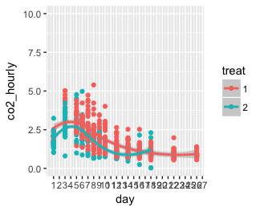

Hourly production of CO2 by mass

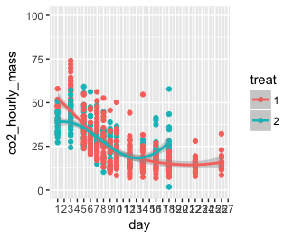

### Page 4: 2018-01-10 USDA

Work Day (short due to A/C service and doctor appt)

1. Checked larvae and added diet to containers as needed
2. Contacted Caitlin concerning LC fault via email
3. Using the FAMEs produced by Erin on 20180109
- prepared an instrument blank
- created a sequence template
- ran all 12 vials and ended with a sleep method to save gas